# Practical 3

OK, let’s see what we can do with our `breakfast` variable.

Basically the only way of visualising a single categorical variable is using the barchart:

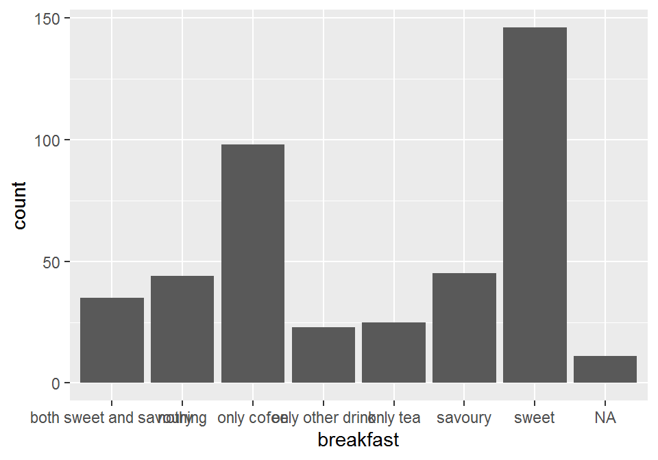

```r
my_data %>%
  ggplot(aes(x = breakfast)) +
  geom_bar()
```

Again, we can customise the plot in several ways. Notice that the bars are ordered alphabetically and their labels are the same as the levels of our `breakfast` variable:

```r
my_data %>%
  pull(breakfast) %>%
  levels()
[1] "both sweet and savoury" "nothing"
[3] "only cofee"             "only other drink"
[5] "only tea"               "savoury"
[7] "sweet"
```

One thing to do would be to capitalise the labels on the x-axis. We already know how to do this from out table above: use the `str_to_sentence()` function.

Another reasonable edit is to order the levels of the variable according to frequency so that the most popular breakfast option is on one end of the plot and the least popular on the other. To do this, we can add the `fct_infreq()` function to the `mutate()` command:

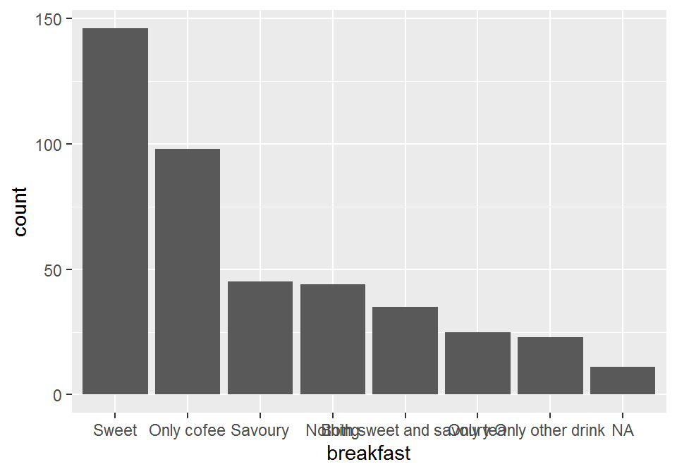

```r
my_data %>%
  mutate(breakfast = str_to_sentence(breakfast),
         breakfast = fct_infreq(breakfast)) %>%
  ggplot(aes(x = breakfast)) +
  geom_bar()
```

*Note* that our two functions inside the `mutate()` commands come before the data are pushed into `ggplot()`. That is because we aren’t really changing the plot itself but the `my_data` tibble. We are essentially telling `R` to change the `breakfast` variable in the tibble so that its levels are capitalised and then change it again so that the levels are ordered according to their frequencies.

Let’s tweak the appearance of our plot using what we already know:

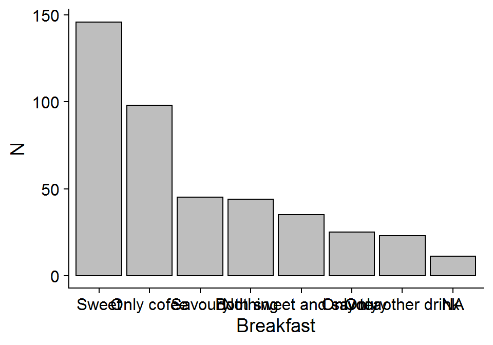

```r
my_data %>%
  mutate(breakfast = str_to_sentence(breakfast),
         breakfast = fct_infreq(breakfast)) %>%
  ggplot(aes(x = breakfast)) +
  geom_bar(color = "black", fill = "grey") +
  labs(x = "Breakfast", y = "N") +
  theme_cowplot()
```

As you can see, we have some overlapping labels. That’s not great. There are several ways around this issue. For instance, we could rotate the labels 45° to stop them from overlapping. However, I think the neatest way is simply to flip the plot on its side. The `coord_flip()` command does exactly that:

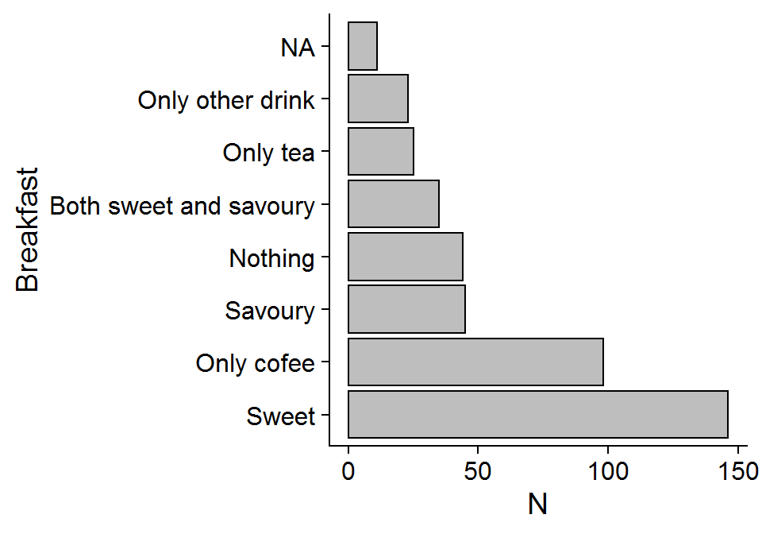

```r
my_data %>%
  mutate(breakfast = str_to_sentence(breakfast),
         breakfast = fct_infreq(breakfast)) %>%
  ggplot(aes(x = breakfast)) +
  geom_bar(color = "black", fill = "grey") +
  labs(x = "Breakfast", y = "N") +
  theme_cowplot() +
  coord_flip()
```

I think this is a nice plot. If you really care about the small things and want the highest frequency categories to be at the top rather than bottom, you can introduce a `fct_rev()` comand into the pipeline after the `fct_infreq()` one. Again, because we’re essentially changing the variable, the command needs to be inside `mutate()`:

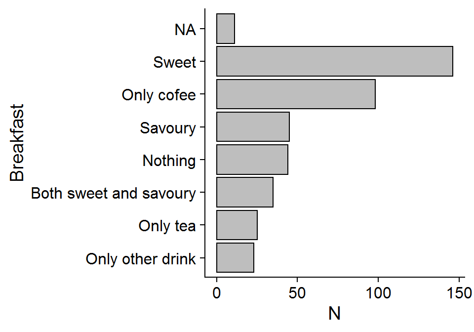

```r
my_data %>%
  mutate(breakfast = str_to_sentence(breakfast),
         breakfast = fct_infreq(breakfast),
         breakfast = fct_rev(breakfast)) %>%
  ggplot(aes(x = breakfast)) +
  geom_bar(color = "black", fill = "grey") +
  labs(x = "Breakfast", y = "N") +
  theme_cowplot() +
  coord_flip()
```

Finally, we can visualise the age breakdown by breakfast choice using boxplots. To do this, you need to map each both of these variables onto one axis inside of the `aes()` function: The categorical variable belongs on the x axis and the continuous on the y axis:

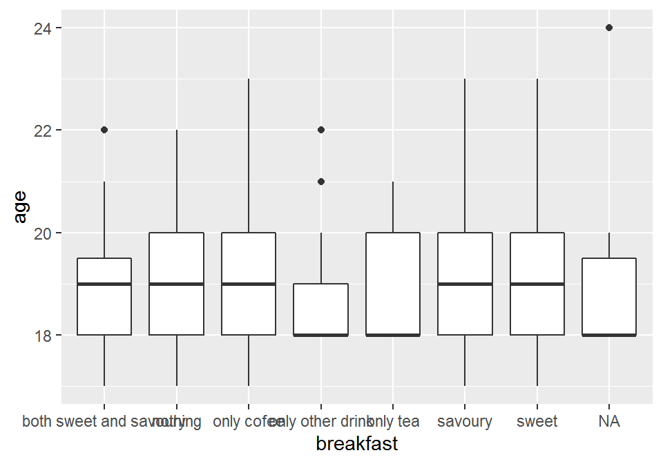

```r
my_data %>%
  ggplot(aes(x = breakfast, y = age)) +
  geom_boxplot()
```

We can re-use essentially all the commands from our previous plot to make this boxplot by group a little nicer.

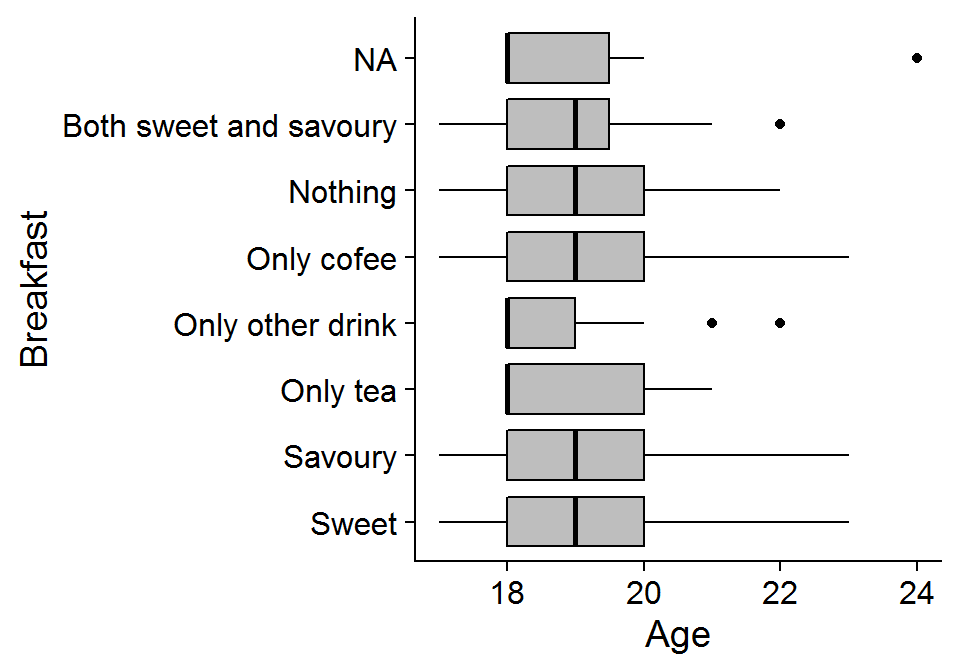

```r
my_data %>%
  mutate(breakfast = str_to_sentence(breakfast),
         breakfast = fct_rev(breakfast)) %>%
  ggplot(aes(x = breakfast, y = age)) +
  geom_boxplot(color = "black", fill = "grey") +
  labs(x = "Breakfast", y = "Age") +
  theme_cowplot() +
  coord_flip()
```

And that’s pretty much all we can do with out data in the way of visualisation. There are many more plots `ggplot()` is capable of creating and many more ways in which to customise plots but, for the time boing, this is plenty.

### Write-up

Now that we are familiar with our data, we can start writing up. Obviously, we don’treally have any results yet but we can at least describe our sample. This is normally done in the *Participants* subsection of the *Method* section. On top of that, we can give a description of what data were collected and how in the *Materials* and *Procedure* subsections, respectively. Here, coth would be very shor so we can collapse them into a single subsection:

#### Method

##### Participants

Data from 427 first year Psychology students at the University of Sussex (*M*<sub>age</sub> = 18.97, *SD*<sub>age</sub> = 1.32) were collected anonymously in class as part of the Analysing Data module.

##### Materials and procedure

Participants filled in a questionnaire hosted via Google Forms. The form was accessed using a URL given in lecture. Each participant was given a unique ID code they then entered into the form. They also provided their age and information on what they had had for breakfast on the day. The latter was done by means of a multiple choice item and the response options available, along with age breakdown by response, are given in Table 1.

Table 1 *Descriptive statistics by breakfast*

| Breakfast | *N* | % | *M*<sub>age</sub> | *SD*<sub>age</sub> |
| --- | --- | --- | --- | --- |
| Both sweet and savoury | 35 | 8.20 | 18.86 | 1.22 |
| Nothing | 44 | 10.30 | 19.12 | 1.33 |
| Only cofee | 98 | 22.95 | 19.05 | 1.45 |
| Only other drink | 23 | 5.39 | 18.70 | 1.11 |
| Only tea | 25 | 5.85 | 18.88 | 1.09 |
| Savoury | 45 | 10.54 | 19.11 | 1.48 |
| Sweet | 146 | 34.19 | 18.92 | 1.25 |
| (Missing) | 11 | 2.58 | 19.00 | 1.84 |

Read through our mock write-up again and notice the following points:

- Concision
  - Make it short and sweet. Above, we only needed one sentence to tell the reader who our participants were, how many there were, what the basic descriptives of their age was, how they were recruited and where and how it all happened.
- Right amount of detail
  - You want to report all the info about your sample that we did. If we knew the gender composition, we would also include it. We *could* also have reported the range of ages but it’s not crucial.
  - In *Material and procedure* we need to give the reader enough information so that they get a good idea of what exactly it is that we did.
- You can refer to tables and figures if it’s helpful

These are all good guidelines for writing up the *Method* section.

That’s all we have to cover this week. Over to you now!

## Worksheet

In the remaining time you will practice what you have just learnt. To make things interesting, let’s use the data from the Gender and sexuality questionnaire we filled in in the lecture. You can find the data at https://…

**Task 1:** First of all, if you haven’t done it yet, download the “01_basic_desc.Rmd” file from canvas and open it in R Studio.

Use the R Markdown file to complete the following tasks.

**Task 2:** In the `packages` code chunk, write the coad to load all the packages you will need to complete this practical: `tidyverse`, `knitr`, `stringr`, and `cowplot` should be enough.

**Task 3:** In the `read-in` code chunk, write the code to read the data into R Studio.

**Task 4:** In the `inspect` chunk, write code that does the following:

**Task 4.1:** Make sure the classes of your variables match the code book: Ordinal variables can be coded as numbers but categorical variables should be factors.

*Hint.* A basic summary will do.

**Task 4.2:** Check if all ID codes are unique.

**Task 5:** Take a minute to look at the summary of the data set. Notice the means and medians of the numeric variables. Think about what the distributions of the variables might look like.

**Task 6:** In the `descriptives` code chunk, write code that creates:

**Task 6.1:** A tibble of descriptive statistics (mean, standard deviation, minimum, maximum) for the `age` variable.

**Task 6.2:** A tibble with *N*s, %s, and age (mean and *SD*) breakdown by categories of the `gender` variable.

**Task 7:** In the `plots` code chunk, write code tat generates the following basic plots:

**Task 7.2:** A barchart of `gender`:

**Task 7.3:** A boxplot of `age` by `gender`:

**Task 8:** If you haven’t formatted your plots yet, change the code in the chunk to generate prettier plots. If you want to, go mad with colours! [Here are some colour names you can use.](http://sape.inf.usi.ch/sites/default/files/ggplot2-colour-names.png)

**Task 9:** Complete the **Write-up** section of the .Rmd file.

**Task 10:** Edit the code in the `table_1` code chunk, giving it your tibble with age breakdown by gender, to create a nice formatted table in your document.

**Task 11:** Knit (generate) the final document from your R markdown file and rejoyce in its beauty.

That’s all for this week. Well done!